# RM 8.5 7DADM — Random Forest Trained on dynamical.org GFS

Maddee Wiggins (FlowWest)

2026-09-16

# Objective

The production random forest (`rm85_rf_7dadm_lead_aware_lead*.rds`, from `rm85-rf-lead-aware.Rmd`) trains its weather trajectory features on Open-Meteo’s `all_historical_forecasts` — confirmed elsewhere in this project to be a “stitched” best-estimate series that returns the same value for a given calendar date regardless of requested lead, not a genuine per-lead forecast product. `data-raw/pull_dynamical_forecasts.py` pulled dynamical.org’s raw GFS archive instead, which genuinely varies by lead (correlation with Open-Meteo decays from r=0.94 at lead 1 to r=0.81 at lead 7 for max temp — `data-raw/dynamical-vs-openmeteo-comparison.Rmd`) and, after fixing a calendar-day aggregation bug in the pull script, agrees closely with Open-Meteo on min temp (bias -0.18°C), with a residual ~2°C cold bias on max temp attributed to Open-Meteo’s elevation downscaling.

A head-to-head comparison against the Open-Meteo-trained production model on the real 2026 hindcast confirmed dynamical.org training wins at every lead (mean bias -1.61°C -> -1.28°C, mean RMSE 1.90 -> 1.64). This document drops that comparison and builds the dynamical.org-trained models directly: same random forest architecture as `rm85-rf-lead-aware.Rmd` — same `fit_rf()` (500 trees, `mtry = floor(features/3)`), same chronological 80/20 split, same feature slots — with the weather trajectory source swapped from Open-Meteo to dynamical.org (`dynamical_gfs_forecasts`). Camp Polk and RM 8.5’s own lag remain sourced from the R package as before; only `air_max_dN`/`air_min_dN`/`cloud_dN` change source. dynamical.org’s archive covers 2021-05-01 onward, so training here spans roughly 4.5 years rather than Open-Meteo’s 14 — less data, but genuinely lead-varying forecast values instead of a proxy that doesn’t change with lead.

Also added here: raw daily Tmax (not the 7-day rolling 7DADM) at both RM 8.5 and Camp Polk. `dadm_m0`/`cp_7dadm` are both smoothed over the prior week, which can lag a fast-developing hot spell; `tmax_m0`/`cp_tmax` give the model a same-day-scale signal alongside the week-smoothed ones.

Both RM 8.5 features (`dadm_m0`, `tmax_m0`) use today’s own value, not yesterday’s — the operational script runs at 7pm PST, and RM 8.5’s daily max occurs by 5-6pm on essentially every day in the real 2026 logger record (0% of days after 7pm, 4.1% after 6pm), so today’s reading is already complete and available at run time, the same as Camp Polk’s real-time telemetry. A 1-day lag here would be needlessly stale.

```r
month_start     <- 5
month_end       <- 10
lead_days_vec   <- c(1:7)
ntree           <- 500
test_frac       <- 0.20
trend_window    <- 5
threshold_7dadm <- 20.0

lead_colors <- setNames(colorRampPalette(c("#185FA5", "#4E9F50", "#C93312"))(length(lead_days_vec)),
                        as.character(lead_days_vec))
```

# Data & feature construction

```r
rm85_7dadm <- rm_8_5_historical |>
  mutate(date = as.Date(date)) |>
  filter(statistic == "7DADM") |>
  select(date, rm_8_5_7dadm = temperature)

rm85_tmax <- rm_8_5_historical |>
  mutate(date = as.Date(date)) |>
  filter(statistic == "max") |>
  select(date, rm_8_5_tmax = temperature)

cp_7dadm <- camp_polk_temperature_historical |>
  mutate(date = as.Date(date)) |>
  filter(statistic == "7DADM") |>
  select(date, cp_7dadm = temperature)

cp_tmax <- camp_polk_temperature_historical |>
  mutate(date = as.Date(date)) |>
  filter(statistic == "max") |>
  select(date, cp_tmax = temperature)

cp_flow <- camp_polk_flow_historical |>
  mutate(date = as.Date(date)) |>
  filter(statistic == "mean") |>
  select(date, cp_flow_mean = flow_cfs)

# Packaged snapshot of data-raw/dynamical_gfs_air_temp_historical.csv. Extend
# the CSV with data-raw/pull_dynamical_forecasts.py, then re-knit the
# dynamical.org chunk in data-raw/pull-historical-data.Rmd to refresh this.
dyn_raw <- dynamical_gfs_forecasts

cat(sprintf("dynamical.org archive: %s to %s, %d rows\n",
            min(dyn_raw$valid_date), max(dyn_raw$valid_date), nrow(dyn_raw)))
```

```
## dynamical.org archive: 2021-05-02 to 2026-09-07, 40929 rows
```

```r
# dynamical.org equivalent of rm85-rf-lead-aware.Rmd's get_forecast() — no
# lead-0 fallback needed since every lead 1-7 here is a genuine forecast
# value (not a proxy that sometimes needs backfilling from an "observed"
# series).
get_forecast_dyn <- function(lead_k) {
  dyn_raw |>
    filter(lead_days == lead_k) |>
    select(valid_date, variable, value) |>
    pivot_wider(names_from = variable, values_from = value) |>
    rename(date = valid_date, air_max = temperature_2m_max,
           air_min = temperature_2m_min, cloud_pct = cloud_cover_mean)
}

get_forecast_trajectory_dyn <- function(lead_k) {
  offsets <- seq_len(lead_k)
  day_tables <- map(offsets, function(k) {
    get_forecast_dyn(k) |>
      mutate(run_date = date - k) |>
      transmute(
        run_date,
        !!paste0("air_max_d", k) := air_max,
        !!paste0("air_min_d", k) := air_min,
        !!paste0("cloud_d",   k) := cloud_pct,
        !!paste0("julian_d",  k) := yday(date)
      )
  })
  reduce(day_tables, full_join, by = "run_date") |> arrange(run_date)
}

build_df_dyn <- function(lead_k) {
  fcst_traj <- get_forecast_trajectory_dyn(lead_k) |>
    mutate(date = run_date + lead_k) |>
    select(-run_date)

  cp_flow_run  <- cp_flow  |> mutate(date = date + lead_k)
  cp_7dadm_run <- cp_7dadm |> mutate(date = date + lead_k)
  cp_tmax_run  <- cp_tmax  |> mutate(date = date + lead_k)

  cp_flow_m1_tbl  <- cp_flow  |> mutate(date = date + lead_k + 1) |> rename(cp_flow_m1 = cp_flow_mean)
  cp_flow_mw_tbl  <- cp_flow  |> mutate(date = date + lead_k + trend_window) |> rename(cp_flow_mw = cp_flow_mean)
  cp_7dadm_m1_tbl <- cp_7dadm |> mutate(date = date + lead_k + 1) |> rename(cp_7dadm_m1 = cp_7dadm)
  cp_7dadm_mw_tbl <- cp_7dadm |> mutate(date = date + lead_k + trend_window) |> rename(cp_7dadm_mw = cp_7dadm)

  # RM 8.5's own same-day 7DADM/Tmax — no lag. The operational script runs
  # at 7pm PST; RM 8.5's daily max empirically occurs by 5-6pm on
  # essentially every observed day in the real 2026 logger record (0% of
  # days after 7pm, 4.1% after 6pm), so today's own reading is already
  # complete and available at run time, the same as Camp Polk's real-time
  # telemetry. A 1-day lag here would be needlessly stale.
  dadm_m0_tbl <- rm85_7dadm |>
    mutate(date = date + lead_k) |>
    rename(dadm_m0 = rm_8_5_7dadm)

  tmax_m0_tbl <- rm85_tmax |>
    mutate(date = date + lead_k) |>
    rename(tmax_m0 = rm_8_5_tmax)

  rm85_7dadm |>
    left_join(cp_flow_run,      by = "date") |>
    left_join(cp_7dadm_run,     by = "date") |>
    left_join(cp_tmax_run,      by = "date") |>
    left_join(fcst_traj,        by = "date") |>
    left_join(cp_flow_m1_tbl,   by = "date") |>
    left_join(cp_flow_mw_tbl,   by = "date") |>
    left_join(cp_7dadm_m1_tbl,  by = "date") |>
    left_join(cp_7dadm_mw_tbl,  by = "date") |>
    left_join(dadm_m0_tbl,      by = "date") |>
    left_join(tmax_m0_tbl,      by = "date") |>
    mutate(
      cp_flow_trend  = (cp_flow_m1  - cp_flow_mw)  / (trend_window - 1),
      cp_7dadm_trend = (cp_7dadm_m1 - cp_7dadm_mw) / (trend_window - 1),
      month  = month(date)
    ) |>
    filter(month >= month_start, month <= month_end) |>
    drop_na() |>
    distinct(date, .keep_all = TRUE) |>
    arrange(date)
}

get_weather_features <- function(lead_k) {
  c("cp_flow_mean", "cp_7dadm", "cp_tmax", "cp_flow_trend", "cp_7dadm_trend",
    paste0("air_max_d", 1:lead_k), paste0("air_min_d", 1:lead_k),
    paste0("cloud_d", 1:lead_k), paste0("julian_d", 1:lead_k))
}
get_persistence_features <- function(lead_k) c(get_weather_features(lead_k), "dadm_m0", "tmax_m0")

split_chronological <- function(df, p = test_frac) {
  df <- df |> arrange(date)
  n  <- nrow(df)
  n_test <- floor(n * p)
  list(
    train = df[seq_len(n - n_test), ],
    test  = df[seq(n - n_test + 1, n), ]
  )
}

# Identical to rm85-rf-lead-aware.Rmd's fit_rf().
fit_rf <- function(train_df, features, target = "rm_8_5_7dadm", seed = 42) {
  set.seed(seed)
  randomForest(
    formula = as.formula(paste(target, "~", paste(features, collapse = " + "))),
    data    = train_df[, c(features, target)],
    ntree   = ntree,
    mtry    = max(1, floor(length(features) / 3)),
    importance = TRUE
  )
}

rmse <- function(pred, obs) sqrt(mean((pred - obs)^2))
```

# Fit dynamical.org-trained models

```r
dyn_dfs <- map(lead_days_vec, build_df_dyn)
names(dyn_dfs) <- as.character(lead_days_vec)

cat("Training row counts by lead (dynamical.org-sourced):\n")
```

```
## Training row counts by lead (dynamical.org-sourced):
```

```r
walk(lead_days_vec, function(k) {
  df <- dyn_dfs[[as.character(k)]]
  cat(sprintf("  Lead %d: n=%d, %s to %s\n", k, nrow(df), min(df$date), max(df$date)))
})
```

```
##   Lead 1: n=673, 2021-05-02 to 2025-10-16
##   Lead 2: n=674, 2021-05-03 to 2025-10-17
##   Lead 3: n=675, 2021-05-04 to 2025-10-18
##   Lead 4: n=676, 2021-05-05 to 2025-10-19
##   Lead 5: n=677, 2021-05-06 to 2025-10-20
##   Lead 6: n=678, 2021-05-07 to 2025-10-21
##   Lead 7: n=679, 2021-05-08 to 2025-10-22
```

```r
dyn_splits <- map(lead_days_vec, function(k) split_chronological(dyn_dfs[[as.character(k)]]))
names(dyn_splits) <- as.character(lead_days_vec)

models_rf_dynamical <- map(lead_days_vec, function(k) {
  fit_rf(dyn_splits[[as.character(k)]]$train, get_persistence_features(k))
})
names(models_rf_dynamical) <- as.character(lead_days_vec)
```

# Test-period performance (within dynamical.org’s own window)

Chronological 80/20 split within the 2021-2025 dynamical.org-sourced training data — comparable in spirit to `rm85-rf-lead-aware.Rmd`’s test table, though on a much shorter, more recent window.

```r
test_metrics <- map_dfr(lead_days_vec, function(k) {
  splits <- dyn_splits[[as.character(k)]]
  model <- models_rf_dynamical[[as.character(k)]]
  pred <- predict(model, splits$test)
  obs <- splits$test$rm_8_5_7dadm
  tibble(lead = k, n = length(obs), bias = mean(pred - obs), rmse = rmse(pred, obs),
         r2 = cor(pred, obs)^2)
})

test_metrics |> kable(digits = 3, col.names = c("Lead (days)", "n", "Bias", "RMSE", "R²"))
```

| Lead (days) | n | Bias | RMSE | R² |
| --- | --- | --- | --- | --- |
| 1 | 134 | -0.028 | 0.365 | 0.989 |
| 2 | 134 | 0.033 | 0.526 | 0.981 |
| 3 | 135 | 0.112 | 0.681 | 0.970 |
| 4 | 135 | 0.174 | 0.772 | 0.964 |
| 5 | 135 | 0.193 | 0.823 | 0.960 |
| 6 | 135 | 0.196 | 0.897 | 0.951 |
| 7 | 135 | 0.173 | 0.923 | 0.946 |

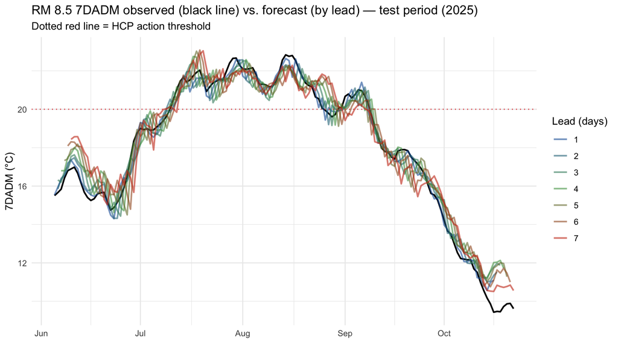

```r
test_long <- map_dfr(lead_days_vec, function(k) {
  splits <- dyn_splits[[as.character(k)]]
  model <- models_rf_dynamical[[as.character(k)]]
  tibble(
    lead = k,
    date = splits$test$date,
    observed = splits$test$rm_8_5_7dadm,
    predicted = predict(model, splits$test)
  )
})

observed_7dadm <- test_long |> distinct(date, observed) |> arrange(date)

ggplot() +
  geom_line(data = observed_7dadm, aes(x = date, y = observed), color = "black", linewidth = 0.8) +
  geom_line(data = test_long, aes(x = date, y = predicted, color = factor(lead)), size = 0.8, alpha = 0.6) +
  geom_hline(yintercept = threshold_7dadm, linetype = "dotted", color = "#E24B4A") +
  scale_color_manual(values = lead_colors, name = "Lead (days)") +
  labs(
    title = "RM 8.5 7DADM observed (black line) vs. forecast (by lead) — test period (2025)",
    subtitle = "Dotted red line = HCP action threshold",
    x = NULL, y = "7DADM (°C)"
  ) +
  theme_minimal()
```

# Variable importance by lead

`%IncMSE` is permutation importance: how much worse the model’s test error gets when a single feature’s values are randomly shuffled, holding everything else fixed. A larger value means the model leans on that feature more heavily.

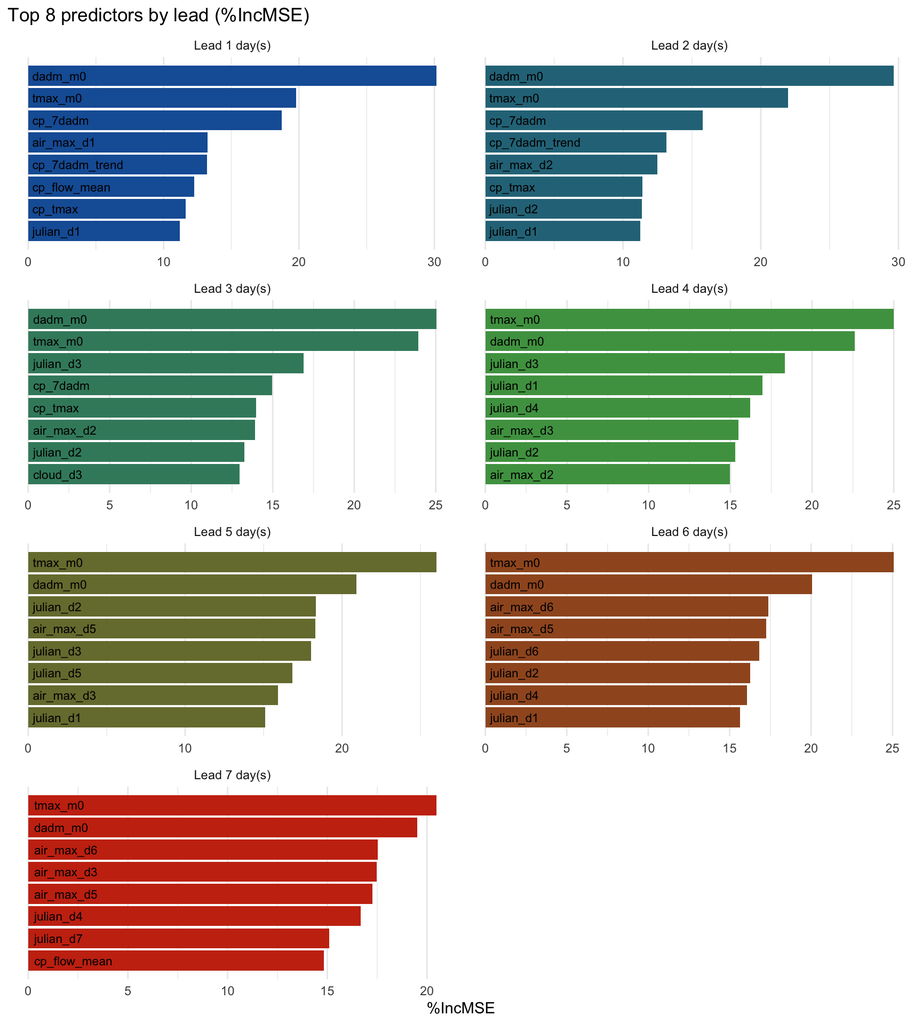

```r
importance_by_lead <- map_dfr(lead_days_vec, function(k) {
  imp <- importance(models_rf_dynamical[[as.character(k)]])
  tibble(lead = k, feature = rownames(imp), pct_inc_mse = imp[, "%IncMSE"])
})

top_n_features <- 8

importance_top <- importance_by_lead |>
  group_by(lead) |>
  slice_max(pct_inc_mse, n = top_n_features) |>
  arrange(lead, pct_inc_mse) |>
  mutate(feature_order = row_number()) |>
  ungroup()

ggplot(importance_top, aes(x = feature_order, y = pct_inc_mse, fill = factor(lead))) +
  geom_col() +
  geom_text(aes(label = feature, y = 0), hjust = 0, size = 3, nudge_y = 0.3) +
  coord_flip() +
  facet_wrap(~lead, scales = "free", ncol = 2, labeller = as_labeller(function(x) paste("Lead", x, "day(s)"))) +
  scale_fill_manual(values = lead_colors, guide = "none") +
  scale_x_continuous(breaks = NULL) +
  labs(
    title = paste("Top", top_n_features, "predictors by lead (%IncMSE)"),
    x = NULL, y = "%IncMSE"
  ) +
  theme_minimal()
```

# Real 2026 hindcast

Same real-data hindcast pipeline as `summer_2026_8_5_performance.Rmd`: cached real NWS forecasts, a fresh Camp Polk pull, and the real RM 8.5 logger record.

```r
nws_cached <- read_csv(here("output", "nws-forecasts-log.csv")) |>
  mutate(run_date = as.Date(run_date), forecast_date = as.Date(forecast_date))

rm_8_5_new <- readxl::read_xlsx(here("data-raw", "data-raw", "WC85 Rimrock bottom 2026-07-01 13_01_25 PDT.xlsx")) |>
  janitor::clean_names()

rm_8_5 <- rm_8_5_new |>
  mutate(date = as.Date(lubridate::floor_date(date_time_pdt, "1 day"))) |>
  group_by(date) |>
  summarize(max = max(temperature_c, na.rm = TRUE)) |>
  mutate(`7DADM` = zoo::rollapply(max, width = 7, FUN = mean, fill = NA, align = "right"))

rm_8_5_wide <- rm_8_5 |> select(date, actual_7dadm_C = `7DADM`, actual_tmax_C = max)

hindcast_run_dates <- nws_cached |>
  distinct(run_date) |>
  filter(run_date %in% rm_8_5_wide$date) |>
  pull(run_date) |>
  sort()

pull_start <- min(hindcast_run_dates) - 10
pull_end   <- max(hindcast_run_dates)

cp_flow_raw <- get_owrd_hydro("14076100", pull_start, pull_end, "MDF")
cp_tmax_raw <- get_owrd_hydro("14076100", pull_start, pull_end, "WTEMP15")

cp_flow_hc <- cp_flow_raw |>
  mutate(date = as.Date(parse_date_time(record_date, orders = c("mdy", "mdy HM")))) |>
  rename(cp_flow_mean = mean_daily_flow_cfs) |>
  select(date, cp_flow_mean) |>
  arrange(date)

cp_tmax_hc <- cp_tmax_raw |>
  mutate(date = as.Date(parse_date_time(record_date, orders = c("mdy", "mdy HM")))) |>
  group_by(date) |>
  summarise(cp_tmax = max(instantaneous_water_temp_c, na.rm = TRUE)) |>
  arrange(date)

cp_7dadm_hc <- cp_tmax_hc |>
  mutate(cp_7dadm = zoo::rollmean(cp_tmax, k = 7, fill = NA, align = "right"))

cp_daily <- cp_flow_hc |>
  left_join(cp_tmax_hc, by = "date") |>
  left_join(select(cp_7dadm_hc, date, cp_7dadm), by = "date")
```

```r
safe1 <- function(x) if (length(x) == 0) NA_real_ else x

nws_daily <- function(var, target_date, agg_fn, run_date_val) {
  vals <- nws_cached |>
    filter(run_date == run_date_val, variable == var, forecast_date == target_date) |>
    pull(value)
  if (length(vals) == 0) return(NA_real_)
  agg_fn(vals, na.rm = TRUE)
}

build_hindcast_row <- function(run_date_val, k) {
  fdate <- run_date_val + k

  cp_today  <- cp_daily |> filter(date == run_date_val)
  cp_yest   <- cp_daily |> filter(date == run_date_val - 1)
  cp_trendw <- cp_daily |> filter(date == run_date_val - trend_window)
  rm85_today <- rm_8_5_wide |> filter(date == run_date_val)

  cp_flow_m1_val  <- safe1(cp_yest$cp_flow_mean)
  cp_7dadm_m1_val <- safe1(cp_yest$cp_7dadm)

  traj <- map(1:k, function(d) {
    tibble(
      !!paste0("air_max_d", d) := nws_daily("maxTemperature", run_date_val + d, max,  run_date_val),
      !!paste0("air_min_d", d) := nws_daily("minTemperature", run_date_val + d, min,  run_date_val),
      !!paste0("cloud_d",   d) := nws_daily("skyCover",       run_date_val + d, mean, run_date_val),
      !!paste0("julian_d",  d) := yday(run_date_val + d)
    )
  }) |> bind_cols()

  bind_cols(
    tibble(
      run_date = run_date_val, forecast_date = fdate, lead_days = k,
      cp_flow_mean   = safe1(cp_today$cp_flow_mean),
      cp_7dadm       = safe1(cp_today$cp_7dadm),
      cp_tmax        = safe1(cp_today$cp_tmax),
      cp_flow_trend  = (cp_flow_m1_val  - safe1(cp_trendw$cp_flow_mean)) / (trend_window - 1),
      cp_7dadm_trend = (cp_7dadm_m1_val - safe1(cp_trendw$cp_7dadm))     / (trend_window - 1)
    ),
    traj,
    tibble(dadm_m0 = safe1(rm85_today$actual_7dadm_C), tmax_m0 = safe1(rm85_today$actual_tmax_C))
  )
}

hindcast_grid   <- expand_grid(run_date = hindcast_run_dates, lead_days = lead_days_vec)
hindcast_inputs <- map2_dfr(hindcast_grid$run_date, hindcast_grid$lead_days, build_hindcast_row)
```

```r
predict_for_lead <- function(k) {
  rows <- hindcast_inputs |> filter(lead_days == k)
  features <- get_persistence_features(k)
  feat_x <- rows |> select(all_of(features))
  ok <- complete.cases(feat_x)

  rows$pred_7dadm_C <- NA_real_
  if (any(ok)) {
    rows$pred_7dadm_C[ok] <- predict(models_rf_dynamical[[as.character(k)]], feat_x[ok, ])
  }
  rows
}

hindcast_results <- map_dfr(lead_days_vec, predict_for_lead)

forecast_eval <- hindcast_results |>
  inner_join(rm_8_5_wide, by = c("forecast_date" = "date")) |>
  filter(!is.na(actual_7dadm_C)) |>
  mutate(lead_days = factor(lead_days, levels = lead_days_vec))

cat(sprintf("Forecast/observation pairs available for evaluation: %d\n", nrow(forecast_eval)))
```

```
## Forecast/observation pairs available for evaluation: 364
```

```r
metrics_table <- forecast_eval |>
  mutate(error = pred_7dadm_C - actual_7dadm_C) |>
  group_by(lead_days) |>
  summarise(n = n(), bias = mean(error, na.rm = TRUE), rmse = sqrt(mean(error^2, na.rm = TRUE)), .groups = "drop")

metrics_table |> kable(digits = 3, col.names = c("Lead (days)", "n", "Bias", "RMSE"))
```

| Lead (days) | n | Bias | RMSE |
| --- | --- | --- | --- |
| 1 | 55 | -0.323 | 0.507 |
| 2 | 54 | -0.386 | 0.638 |
| 3 | 53 | -0.602 | 0.877 |
| 4 | 52 | -0.845 | 1.138 |
| 5 | 51 | -1.029 | 1.391 |
| 6 | 50 | -1.309 | 1.712 |
| 7 | 49 | -1.611 | 2.007 |

```r
metrics_table |>
  summarise(mean_bias = mean(bias), mean_rmse = mean(rmse)) |>
  kable(digits = 3, col.names = c("Mean bias (across leads)", "Mean RMSE (across leads)"))
```

| Mean bias (across leads) | Mean RMSE (across leads) |
| --- | --- |
| -0.872 | 1.181 |

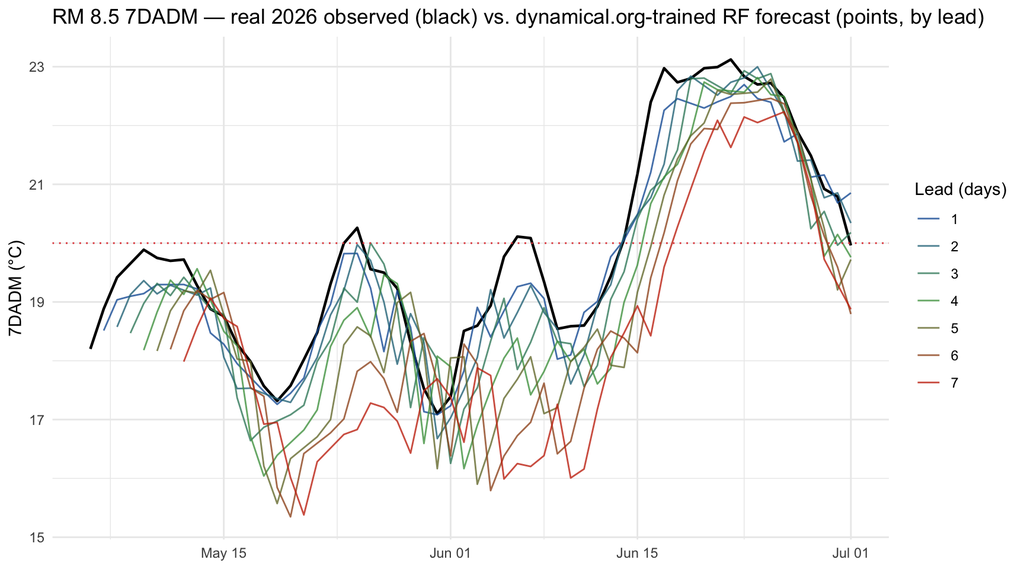

```r
ggplot(forecast_eval, aes(x = forecast_date)) +
  geom_line(aes(y = actual_7dadm_C), color = "black", linewidth = 0.8) +
  geom_line(aes(y = pred_7dadm_C, color = lead_days), alpha = 0.8) +
  geom_hline(yintercept = threshold_7dadm, linetype = "dotted", color = "#E24B4A") +
  scale_color_manual(values = lead_colors) +
  labs(
    title = "RM 8.5 7DADM — real 2026 observed (black) vs. dynamical.org-trained RF forecast (points, by lead)",
    x = NULL, y = "7DADM (°C)", color = "Lead (days)"
  ) +
  theme_minimal()
```

# Threshold-exceedance performance

Beyond raw temperature error, what matters operationally is whether the forecast correctly flags days that cross the HCP action threshold (7DADM >= 20°C). “Exceedance” here means 7DADM at or above that threshold — `actual_exceed` for the real observation, `pred_exceed` for the forecast. Each forecast/observation pair falls into one of four outcomes:

- **True positive (TP)**: forecast predicted exceedance, and it actually happened.
- **True negative (TN)**: forecast predicted no exceedance, and none happened.
- **False positive (FP)**: forecast predicted exceedance, but it didn’t happen (a false alarm).
- **False negative (FN)**: forecast predicted no exceedance, but one happened (a missed exceedance).

The four metrics below are standard confusion-matrix rates built from those counts:

- **Accuracy** = (TP + TN) / n — the share of all forecasts that got the exceed/no-exceed call right, in either direction.
- **Sensitivity** (a.k.a. recall) = TP / (TP + FN) — of the days that actually exceeded, the fraction the model caught. Low sensitivity means missed exceedances — the operationally riskier failure mode, since it means the model didn’t warn when it should have.
- **Specificity** = TN / (TN + FP) — of the days that did *not* exceed, the fraction correctly left unflagged. Low specificity means false alarms.
- **Precision** = TP / (TP + FP) — of the days the model *did* flag as exceeding, the fraction that actually did. Low precision means the flag isn’t trustworthy even when raised.

```r
exceedance_eval <- forecast_eval |>
  mutate(
    actual_exceed = actual_7dadm_C >= threshold_7dadm,
    pred_exceed   = pred_7dadm_C >= threshold_7dadm
  )

confusion_summary <- function(df, pred_col, actual_col) {
  df <- df |> filter(!is.na({{ pred_col }}), !is.na({{ actual_col }}))
  pred <- df |> pull({{ pred_col }}); actual <- df |> pull({{ actual_col }})
  tp <- sum(pred & actual); tn <- sum(!pred & !actual)
  fp <- sum(pred & !actual); fn <- sum(!pred & actual)
  tibble(n = nrow(df), accuracy = (tp + tn) / nrow(df),
         sensitivity = if (tp + fn > 0) tp / (tp + fn) else NA_real_,
         specificity = if (tn + fp > 0) tn / (tn + fp) else NA_real_,
         precision   = if (tp + fp > 0) tp / (tp + fp) else NA_real_)
}

exceedance_eval |>
  group_by(lead_days) |>
  group_modify(~ confusion_summary(.x, pred_exceed, actual_exceed)) |>
  ungroup() |>
  kable(digits = 2, col.names = c("Lead (days)", "n", "Accuracy", "Sensitivity", "Specificity", "Precision"))
```

| Lead (days) | n | Accuracy | Sensitivity | Specificity | Precision |
| --- | --- | --- | --- | --- | --- |
| 1 | 54 | 0.93 | 0.84 | 0.97 | 0.94 |
| 2 | 53 | 0.92 | 0.84 | 0.97 | 0.94 |
| 3 | 52 | 0.87 | 0.74 | 0.94 | 0.88 |
| 4 | 51 | 0.88 | 0.68 | 1.00 | 1.00 |
| 5 | 50 | 0.86 | 0.63 | 1.00 | 1.00 |
| 6 | 49 | 0.86 | 0.63 | 1.00 | 1.00 |
| 7 | 48 | 0.81 | 0.53 | 1.00 | 1.00 |

# Saved artifacts

```r
walk(lead_days_vec, function(k) {
  saveRDS(models_rf_dynamical[[as.character(k)]],
          here("output", paste0("rm85_rf_7dadm_dynamical_lead", k, ".rds")))
})
cat("Models saved to output/rm85_rf_7dadm_dynamical_lead*.rds\n")
```

```
## Models saved to output/rm85_rf_7dadm_dynamical_lead*.rds
```